## Agenda

- build histogram
- specify bins
- modify
  - color
  - fill
  - alpha
  - bin width
  - line type
  - line size
- map aesthetics to variables

## Intro

A histogram is a plot that can be used to examine the shape and spread of continuous data. It looks very similar to a bar graph and can be used to detect outliers and skewness in data. The histogram graphically shows the following:

- center (location) of the data
- spread (dispersion) of the data
- skewness
- outliers
- presence of multiple modes

## Histograms

To construct a histogram

- the data is split into intervals called bins
- the intervals may or may not be equal sized
- for each bin, the number of data points that fall into it are counted (frequency)
- the Y axis of the histogram represents the frequency and
- the X axis represents the variable

## Libraries

```r
library(ggplot2)
library(dplyr)
library(tidyr)
```

## Data

```r
ecom <- readr::read_csv('https://raw.githubusercontent.com/rsquaredacademy/datasets/master/web.csv')
```

```
## # A tibble: 1,000 x 11
##       id referrer device bouncers n_visit n_pages duration        country
##    <int>    <chr>  <chr>    <chr>   <int>   <dbl>    <dbl>          <chr>
##  1     1   google laptop     true      10       1      693 Czech Republic
##  2     2    yahoo tablet     true       9       1      459          Yemen
##  3     3   direct laptop     true       0       1      996         Brazil
##  4     4     bing tablet    false       3      18      468          China
##  5     5    yahoo mobile     true       9       1      955         Poland
##  6     6    yahoo laptop    false       5       5      135   South Africa
##  7     7    yahoo mobile     true      10       1       75     Bangladesh
##  8     8   direct mobile     true      10       1      908      Indonesia
##  9     9     bing mobile    false       3      19      209    Netherlands
## 10    10   google mobile     true       6       1      208 Czech Republic
## # ... with 990 more rows, and 3 more variables: purchase <chr>,
## #   order_items <dbl>, order_value <dbl>
```

## Data Dictionary

- id: row id
- referrer: referrer website/search engine
- os: operating system
- browser: browser
- device: device used to visit the website
- n_pages: number of pages visited
- duration: time spent on the website (in seconds)
- repeat: frequency of visits
- country: country of origin
- purchase: whether visitor purchased
- order_value: order value of visitor (in dollars)

## Histogram

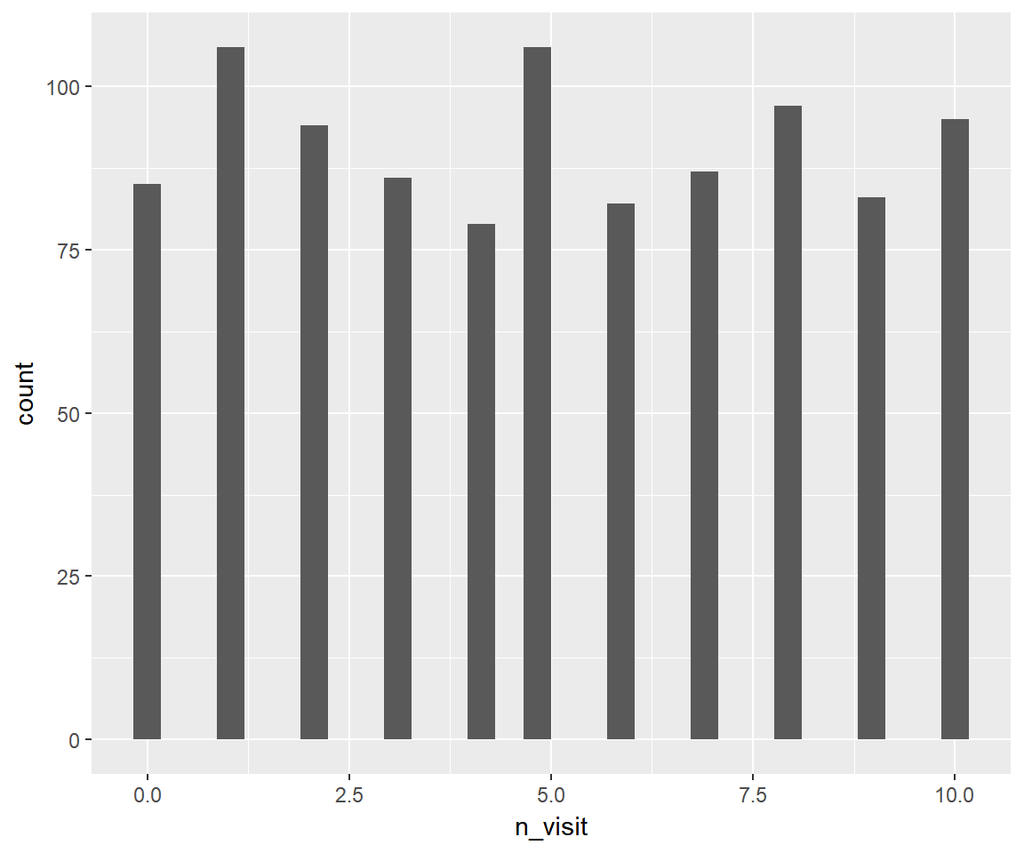

```r
ggplot(ecom) +
  geom_histogram(aes(n_visit))
```

## Specify Bins

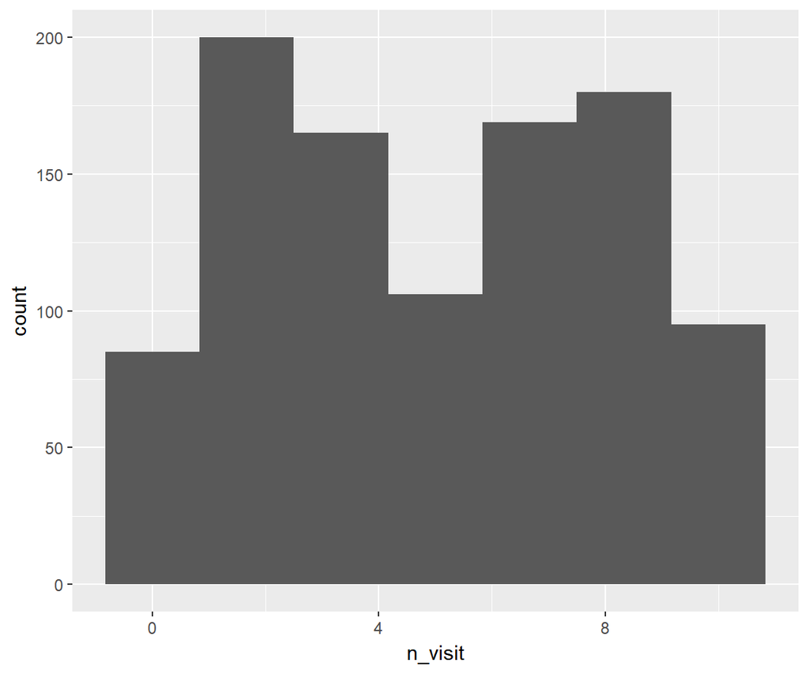

```r
ggplot(ecom) +
  geom_histogram(aes(n_visit), bins = 7)
```

## Fill

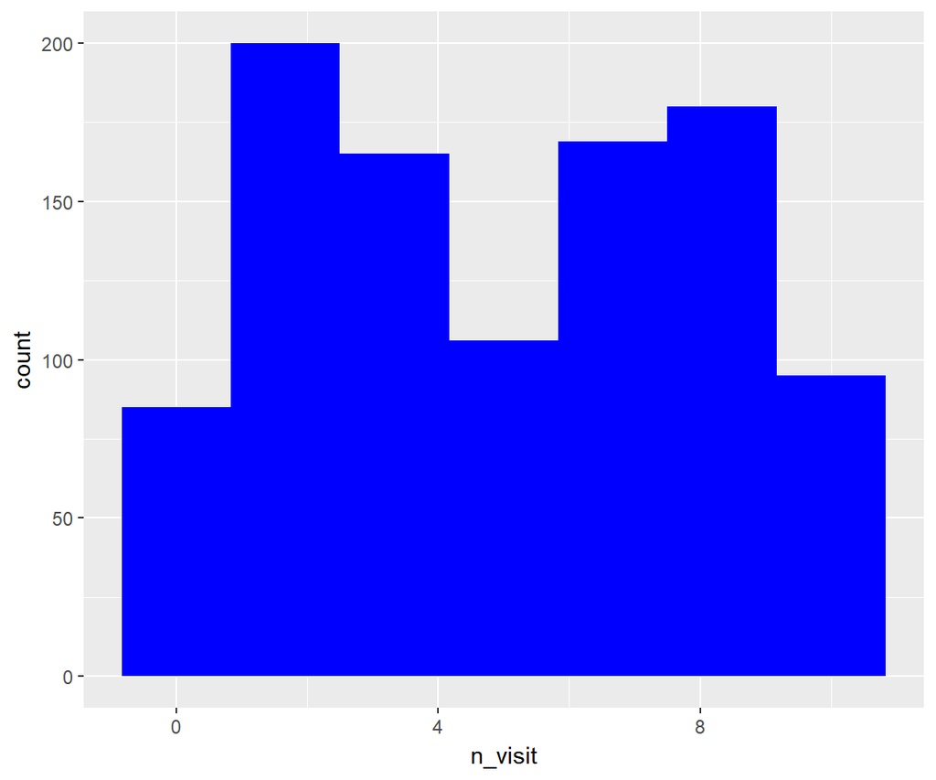

```r
ggplot(ecom) +
  geom_histogram(aes(n_visit), bins = 7, fill = 'blue')
```

## Alpha

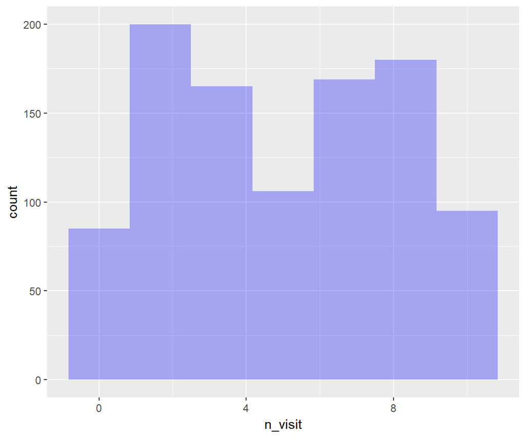

```r
ggplot(ecom) +
  geom_histogram(aes(n_visit), bins = 7, fill = 'blue', alpha = 0.3)
```

## Color

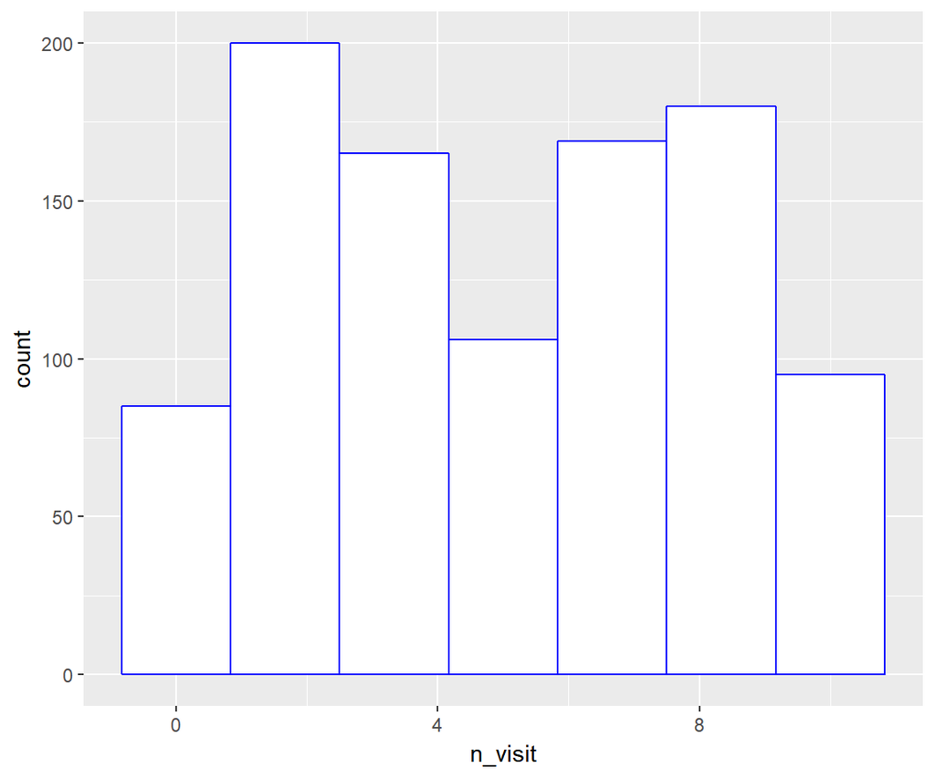

```r
ggplot(ecom) +
  geom_histogram(aes(n_visit), bins = 7, fill = 'white', color = 'blue')
```

## Bins, Color & Fill

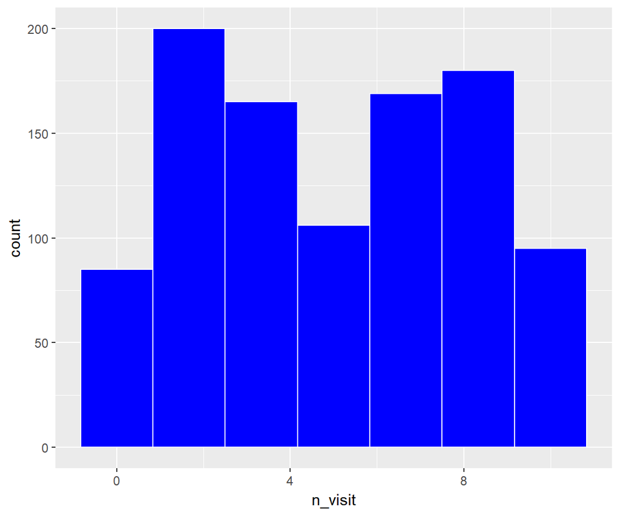

```r
ggplot(ecom) +
  geom_histogram(aes(n_visit), bins = 7, fill = 'blue', color = 'white')
```

## Bin Width

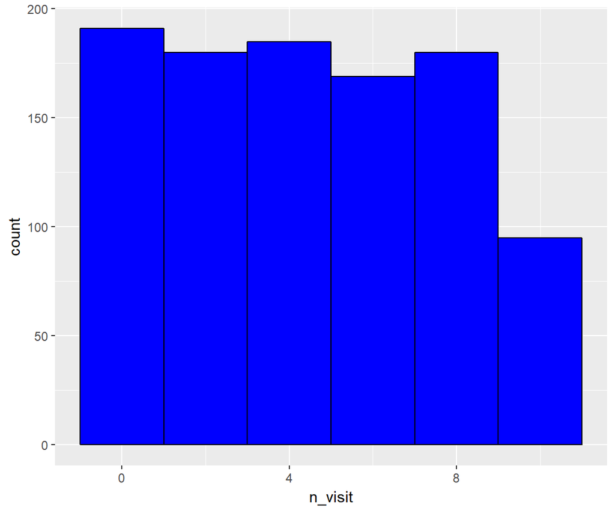

```r
ggplot(ecom) +
  geom_histogram(aes(n_visit), binwidth = 2, fill = 'blue', color = 'black')
```

## Line Type

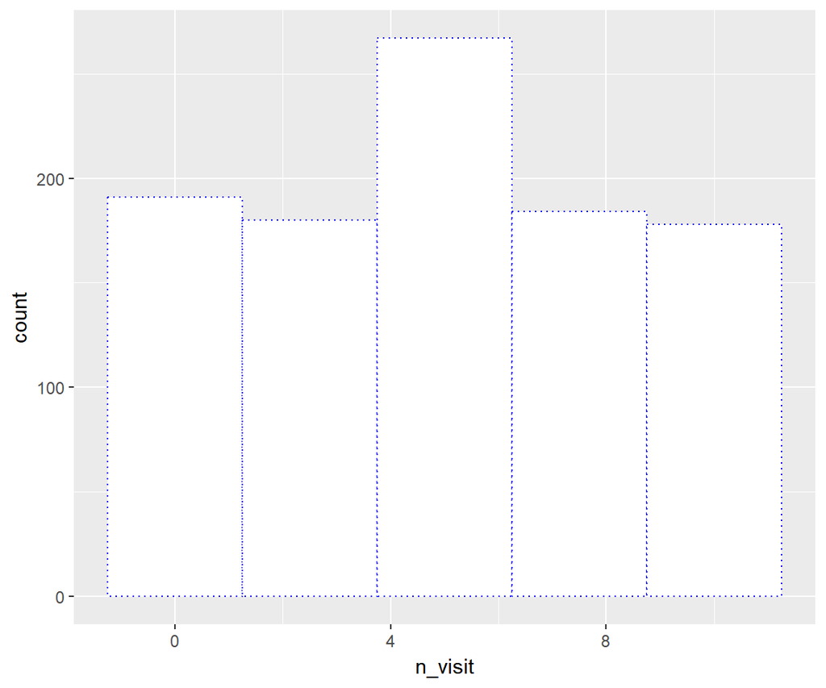

```r
ggplot(ecom) +
  geom_histogram(aes(n_visit), bins = 5, fill = 'white',
    color = 'blue', linetype = 3)
```

## Line Size

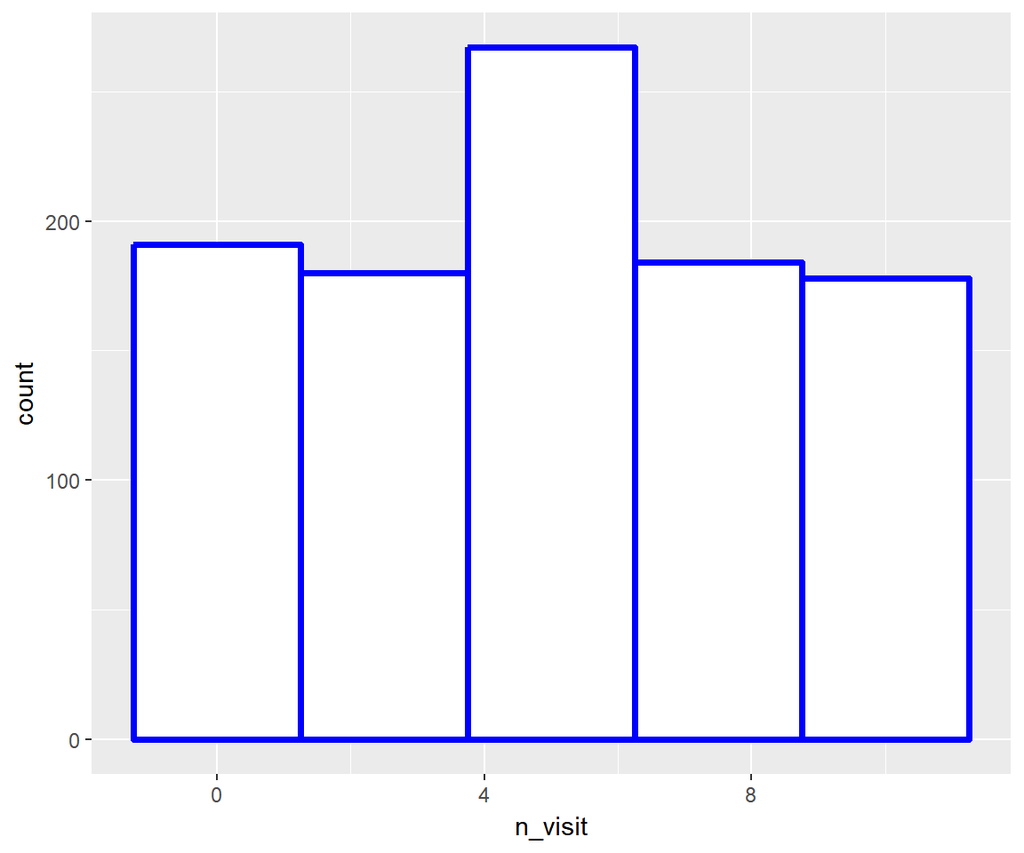

```r
ggplot(ecom) +
  geom_histogram(aes(n_visit), bins = 5, fill = 'white',
    color = 'blue', size = 1.25)
```

## Map Fill to Variable

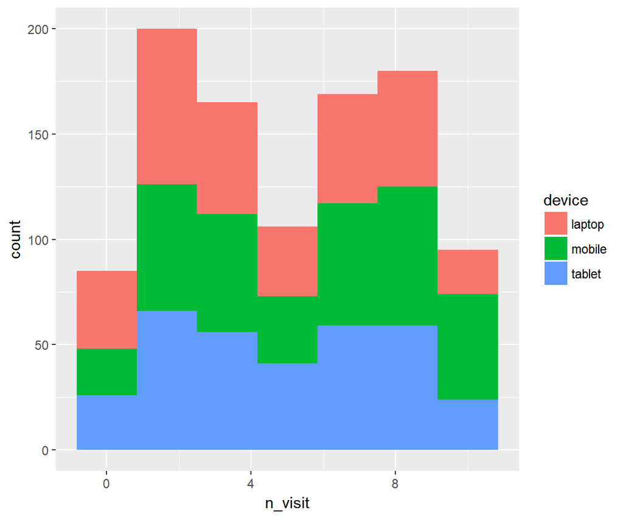

```r
ggplot(ecom) +
  geom_histogram(aes(n_visit, fill = device), bins = 7)
```